# Midterm

Kristina Becvar

7/30/2021

# **Reading in the data:**

## This assumes that the data file is in the same folder as the RMarkdown and not in a separate file.

### If it were in a separate file, we would need to use ../ to tell R to look up and then in another level of files.

```r
flag.colors <- read.delim("flag-colors.csv", sep = ",", header  = TRUE)
```

# *1. In a paragraph or two, describe these data. What are they? What questions could you answer from them? How many observations are there? How many variables? How much missing data and on which variables?*

## The data in this file represent the countries of the world, along with the location of the country by geographic landmass and quadrant, as well as demographic data about each country. In addition, it contains data on the specifics details of each country’s flag (e.g. colors, bars, stripes). Although the dataset does include these details on the flags of each country, the demographic and geographic data make it a versatile tool for looking at geographic observations of religion, language, population, location, and of course how those factors might correlate with features of the countries’ flags.

```r
dim(flag.colors)
```

```
## [1] 194  18
```

```r
(flag.tibble <- as_tibble(flag.colors))
```

```
## # A tibble: 194 x 18
##    Name  Landmass  Zone  Area Population Language Religion  Bars Stripes Colours
##    <chr>    <int> <int> <int>      <int>    <int>    <int> <int>   <int>   <int>
##  1 Afgh~        5     1   648         NA       10        2     0       3       5
##  2 Alba~        3     1    29          3        6        6     0       0       3
##  3 Alge~        4     1  2388         20        8        2     2       0       3
##  4 Amer~        6     3     0          0        1        1     0       0       5
##  5 Ando~        3     1     0          0        6        0     3       0       3
##  6 Ango~        4     2  1247          7       10        5     0       2       3
##  7 Angu~        1     4     0          0        1        1     0       1       3
##  8 Anti~        1     4     0          0        1        1     0       1       5
##  9 Arge~        2     3  2777         28        2        0     0       3       2
## 10 Arge~        2     3  2777         28        2        0     0       3       3
## # ... with 184 more rows, and 8 more variables: Red <int>, Green <int>,
## #   Blue <int>, Gold <int>, White <int>, Black <int>, Orange <int>,
## #   mainhue <chr>
```

```r
flag.tibble[!complete.cases(flag.tibble),]
```

```
## # A tibble: 10 x 18
##    Name  Landmass  Zone  Area Population Language Religion  Bars Stripes Colours
##    <chr>    <int> <int> <int>      <int>    <int>    <int> <int>   <int>   <int>
##  1 Afgh~        5     1   648         NA       10        2     0       3       5
##  2 Bots~        4     2   600         NA       10        5     0       5       3
##  3 Como~        4     2    NA          0        3        2     0       0       2
##  4 Faer~        3     4    NA          0        6        1     0       0       3
##  5 Kuwa~        5     1    18         NA        8        2     0       3       4
##  6 Mona~        3     1    NA          0        3        0     0       2       2
##  7 Niue         6     3    NA         NA        1        1     0       0       4
##  8 Sout~        4     2  1221         NA        6        1     0       3       5
##  9 Ugan~        4     1    NA         13       10        5     0       6       5
## 10 Zimb~        4     2   391         NA       10        5     0       7       5
## # ... with 8 more variables: Red <int>, Green <int>, Blue <int>, Gold <int>,
## #   White <int>, Black <int>, Orange <int>, mainhue <chr>
```

## The dimensions of the dataset are 194 observations of 18 variables. Evaluating the dataset for missing data, it is missing observations for area and population for a combined total of 10 of the countries observed.

# *2. If you filter out cases with incomplete data, how many cases are there? As you go through each of the following tasks, try to use as many cases as possible. If you need to drop cases, tell me how many you dropped and why.*

## Filtering cases with incomplete data would leave us with 184 observations. However, coming back to this later, I realize that I need to drop more cases - 62 total in order to have data in the population and area columns that is greater than “0”.

# *3. Recode the population variable to reflect that it is in millions.*

```r
(flag.tibble$Population <- flag.tibble$Population * 1000000)
```

```
##   [1]        NA 3.000e+06 2.000e+07 0.000e+00 0.000e+00 7.000e+06 0.000e+00
##   [8] 0.000e+00 2.800e+07 2.800e+07 1.500e+07 8.000e+06 0.000e+00 0.000e+00
##  [15] 9.000e+07 0.000e+00 1.000e+07 0.000e+00 3.000e+06 0.000e+00 1.000e+06
##  [22] 6.000e+06        NA 1.190e+08 0.000e+00 0.000e+00 9.000e+06 7.000e+06
##  [29] 3.500e+07 4.000e+06 8.000e+06 2.400e+07 0.000e+00 0.000e+00 2.000e+06
##  [36] 4.000e+06 1.100e+07 1.008e+09 2.800e+07 0.000e+00 2.000e+06 0.000e+00
##  [43] 2.000e+06 1.000e+07 1.000e+06 1.500e+07 5.000e+06 0.000e+00 0.000e+00
##  [50] 6.000e+06 8.000e+06 4.700e+07 5.000e+06 0.000e+00 3.100e+07 0.000e+00
##  [57] 0.000e+00 1.000e+06 5.000e+06 5.400e+07 0.000e+00 0.000e+00 1.000e+06
##  [64] 1.000e+06 1.700e+07 6.100e+07 1.400e+07 0.000e+00 1.000e+07 0.000e+00
##  [71] 0.000e+00 0.000e+00 8.000e+06 6.000e+06 1.000e+06 1.000e+06 6.000e+06
##  [78] 4.000e+06 5.000e+06 1.100e+07 0.000e+00 6.840e+08 1.570e+08 3.900e+07
##  [85] 1.400e+07 3.000e+06 4.000e+06 5.700e+07 7.000e+06 2.000e+06 1.180e+08
##  [92] 2.000e+06 6.000e+06 1.700e+07 0.000e+00        NA 3.000e+06 3.000e+06
##  [99] 1.000e+06 1.000e+06 3.000e+06 0.000e+00 0.000e+00 9.000e+06 6.000e+06
## [106] 1.300e+07 0.000e+00 7.000e+06 0.000e+00 0.000e+00 2.000e+06 1.000e+06
## [113] 7.700e+07 0.000e+00 0.000e+00 2.000e+06 0.000e+00 2.000e+07 1.200e+07
## [120] 0.000e+00 1.600e+07 1.400e+07 0.000e+00 2.000e+06 3.000e+06 5.000e+06
## [127] 5.600e+07        NA 1.800e+07 9.000e+06 4.000e+06 1.000e+06 8.400e+07
## [134] 2.000e+06 3.000e+06 3.000e+06 1.400e+07 4.800e+07 3.600e+07 1.000e+07
## [141] 3.000e+06 0.000e+00 2.200e+07 5.000e+06 0.000e+00 0.000e+00 9.000e+06
## [148] 6.000e+06 0.000e+00 3.000e+06 3.000e+06 0.000e+00 5.000e+06        NA
## [155] 3.900e+07 2.000e+06 3.800e+07 1.500e+07 0.000e+00 0.000e+00 0.000e+00
## [162] 0.000e+00 2.000e+07 0.000e+00 1.000e+06 8.000e+06 6.000e+06 1.000e+07
## [169] 1.800e+07 1.800e+07 4.900e+07 2.000e+06 0.000e+00 1.000e+06 7.000e+06
## [176] 4.500e+07 0.000e+00 0.000e+00 1.000e+06 1.300e+07 5.600e+07 3.000e+06
## [183] 0.000e+00 2.310e+08 2.740e+08 0.000e+00 0.000e+00 1.500e+07 6.000e+07
## [190] 0.000e+00 2.200e+07 2.800e+07 6.000e+06        NA
```

# *4. How should you recode the area variable (hint: look in the variable names file)? Recode the variable*

## Since the number represented in the dataset was the number in thousands, I muliplied it out to get the actual number representing the area.

```r
(flag.tibble$Area <- flag.tibble$Area * 1000)
```

```
##   [1]   648000    29000  2388000        0        0  1247000        0        0
##   [9]  2777000  2777000  7690000    84000    19000     1000   143000        0
##  [17]    31000    23000   113000        0    47000  1099000   600000  8512000
##  [25]        0     6000   111000   274000   678000    28000   474000  9976000
##  [33]     4000        0   623000  1284000   757000  9561000  1139000       NA
##  [41]   342000        0    51000   115000     9000   128000    43000    22000
##  [49]        0    49000   284000  1001000    21000    28000  1222000       NA
##  [57]    12000    18000   337000   547000    91000     4000   268000    10000
##  [65]   108000   249000   239000        0   132000  2176000        0        0
##  [73]   109000   246000    36000   215000    28000   112000     1000    93000
##  [81]   103000  3268000  1904000  1648000   435000    70000    21000   301000
##  [89]   323000    11000   372000    98000   181000   583000        0    18000
##  [97]   236000    10000    30000   111000  1760000        0     3000   587000
## [105]   118000   333000        0  1240000        0        0  1031000     2000
## [113]  1973000     1000       NA  1566000        0   447000   783000        0
## [121]   140000    41000        0   268000   128000  1267000   925000       NA
## [129]   121000   195000   324000   212000   804000    76000   463000   407000
## [137]  1285000   300000   313000    92000     9000    11000   237000    26000
## [145]        0        0  2150000   196000        0    72000     1000    30000
## [153]   637000  1221000    99000   288000   505000    66000        0        0
## [161]        0        0  2506000    63000    17000   450000    41000   185000
## [169]    36000   945000   514000    57000     1000     5000   164000   781000
## [177]        0        0    84000       NA   245000   178000        0  9363000
## [185] 22402000    15000        0   912000   333000     3000   256000   905000
## [193]   753000   391000
```

# *6. Create a new variable that says whether a country is densely populated or not. It is up to you how you define “densely population”, but just tell me how you defined it.*

## I divided the population by the area of each country;

```r
(flag.tibble$density <- flag.tibble$Population / flag.tibble$Area)
```

```
##   [1]          NA  103.448276    8.375209         NaN         NaN    5.613472
##   [7]         NaN         NaN   10.082823   10.082823    1.950585   95.238095
##  [13]    0.000000    0.000000  629.370629         NaN  322.580645    0.000000
##  [19]   26.548673         NaN   21.276596    5.459509          NA   13.980263
##  [25]         NaN    0.000000   81.081081   25.547445   51.622419  142.857143
##  [31]   16.877637    2.405774    0.000000         NaN    3.210273    3.115265
##  [37]   14.531044  105.428302   24.582968          NA    5.847953         NaN
##  [43]   39.215686   86.956522  111.111111  117.187500  116.279070    0.000000
##  [49]         NaN  122.448980   28.169014   46.953047  238.095238    0.000000
##  [55]   25.368249          NA    0.000000   55.555556   14.836795   98.720293
##  [61]    0.000000    0.000000    3.731343  100.000000  157.407407  244.979920
##  [67]   58.577406         NaN   75.757576    0.000000         NaN         NaN
##  [73]   73.394495   24.390244   27.777778    4.651163  214.285714   35.714286
##  [79] 5000.000000  118.279570    0.000000  209.302326   82.457983   23.665049
##  [85]   32.183908   42.857143  190.476190  189.368771   21.671827  181.818182
```

[output cut: 18 more lines]

## I then decided that I would consider density over 200 as “high population density”.

```r
flag.tibble <- flag.tibble %>%
  mutate(density = case_when(
    density > 200 ~ "high density",
    density <= 200 ~ "not high density"
  ))
```

## After creating this new variable, I ran another “complete.cases” function and found that there were many more issues, as creating the density column created “NaN”, not a number, indicators where there had been data in the area variable column, but that data was “0”. Dividing by “0” created the “NaN”, so I ran another “drop.na” to discard the additional incomplete cases, leaving 152 complete cases.

### However, that made me realize that my population vs. area visualization included a lot of “0” values, so I should filter those when using that variable.

```r
tidy.flag <- filter(flag.tibble,
                    Population > 0,
                    Area > 0)
```

# *5. Do larger countries have larger populations (show this in a figure).*

## I selected the categories I intend to compare

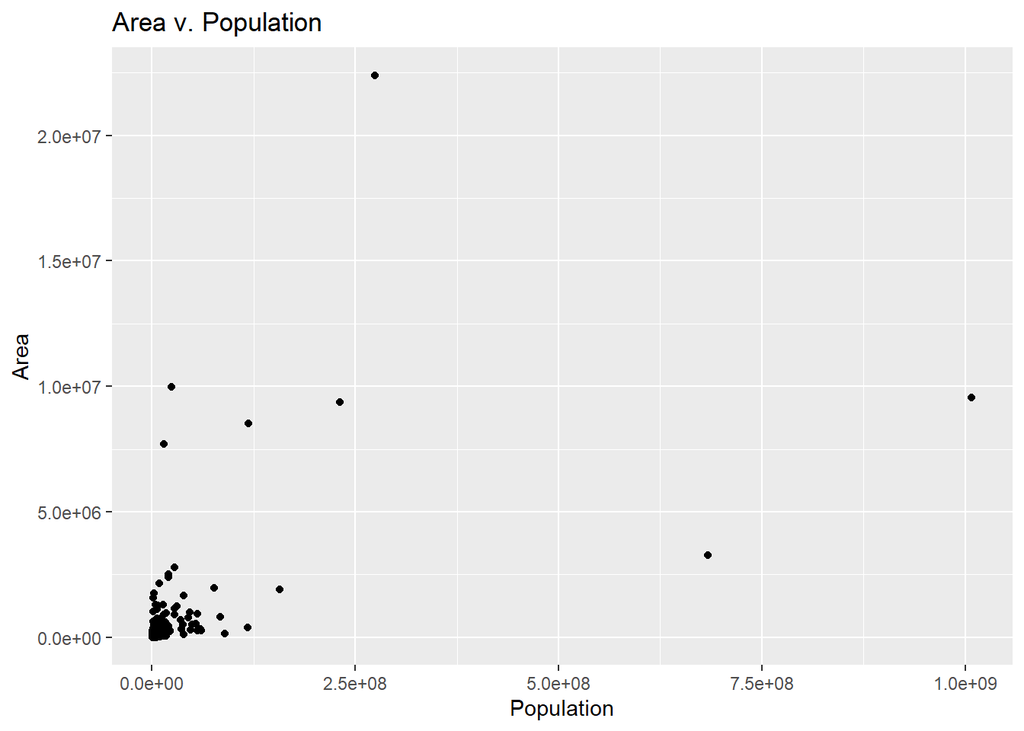

```r
tidy.flag %>%
  ggplot(aes(x = Population, y = Area)) +
  geom_point() +
  ggtitle("Area v. Population")
```

# *7. Do countries with different religions have different population sizes, population densities, or geographical areas. Describe this in numbers and at least one figure.*

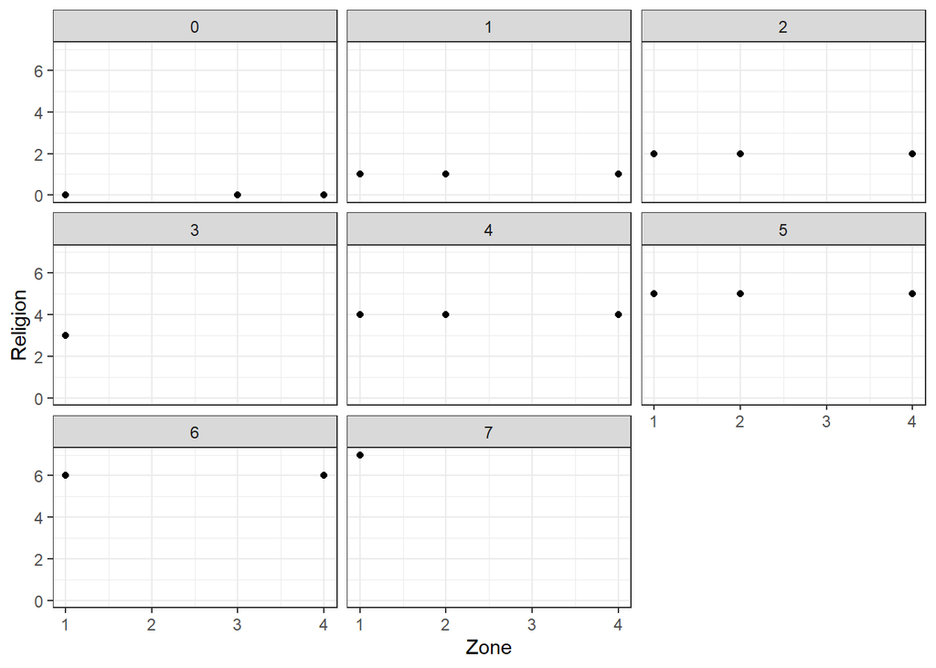

```r
ggplot(data=tidy.flag, mapping = aes(x = Zone, y = Religion)) +
  geom_point() +
  facet_wrap(~Religion) +
  theme_bw()
```

# *8. Are the main hue of the flag and the religion related at all?*

## These variables do not seem to be related at all.

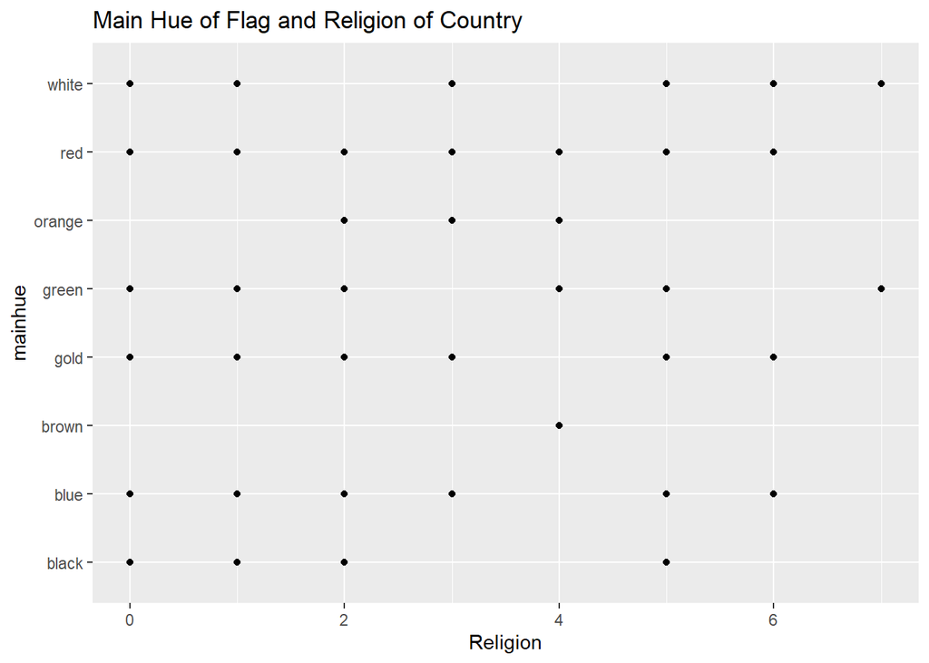

```r
tidy.flag %>%
  ggplot(aes(x = Religion , y = mainhue)) +
  geom_point() +
  ggtitle("Main Hue of Flag and Religion of Country")
```

# *9. Look at the relationship between one other flag characteristics and any of the non-flag characteristics. Describe any relationship (or lack of relationship) that you find and use figures to show it as well.*

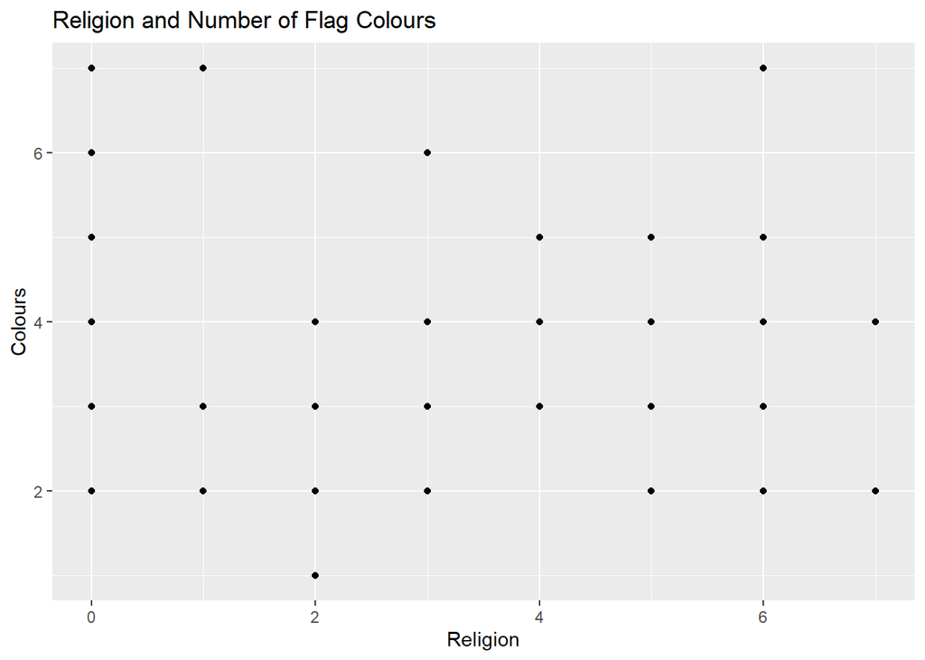

```r
tidy.flag %>%
  ggplot(aes(x = Religion , y = Colours)) +
  geom_point() +
  ggtitle("Religion and Number of Flag Colours")
```